# Identification of best practices for county-level data reporting on COVID-19 dashboards

May 18th, 2021

## Acknowledgements

Texas Policy Lab staff and interns:

- Megan S. Rafferty, MPH
- Connor L. Rothschild
- Idalina Sachango
- Jake P. Joseph
- Spoorthi Kamepalli
- Prayag Gordy
- Dr. Snejana Nihtianova, Ph.D.
- Dr. E. Susan Amirian, Ph.D.

## Agenda

- Background
- Methods
  - Sample
- Evaluation criteria
- Evaluation results
  - Public accessibility
  - Epidemiologic completeness
- Conclusion

## Background

- County COVID-19 dashboards provide crucial public health information to constituents, stakeholders, and policymakers
- The development of dashboard-related best practices can help health departments optimize the public utility and epidemiologic rigor of their dashboards
- The implementation of best practices can improve health equity by providing communities with standardized metrics of risk from COVID-19 transmission

## Evaluation criteria

| Category | Number | Public accessibility |
| --- | --- | --- |
| Accessibility | 1 | Dashboard is interactive |
|  | 2 | Translated into multiple languages |
| Communication | 1 | County level risk score is shown |
|  | 2 | Documentation is provided on how risk score links to epidemiological indicators |
|  | 3 | Dashboard provides definitions of epidemiological terms/indicators |
| Data integrity and system quality | 1 | Data sources are clearly labeled |
|  | 2 | Data sources are a county or state public health authority |
|  | 3 | Date the data were last updated is clearly labeled |
|  | 4 | Data were last updated within the last 2 days or less |
|  | 5 | A member of the public can download the data |

| Category | Number | Epidemiological completeness |
| --- | --- | --- |
| Disease situation | 1 | Dashboard reports daily new cases at the county level |
|  | 2 | Dashboard reports daily new cases per capita at the county level |
|  | 3 | Dashboard reports daily new cases with a moving average at the county level |
|  | 4 | Dashboard reports confirmed and probable cases at the county level |
|  | 5 | Dashboard reports case data stratified by any demographics (e.g. sex, race/ethnicity, age) at the county level |
|  | 6 | Dashboard reports daily deaths at the county level |
|  | 7 | Dashboard reports daily deaths per capita at the county level |
|  | 8 | Dashboard reports daily deaths with a moving average at the county level |
|  | 9 | Dashboard reports confirmed and probable deaths at the county level |
|  | 10 | Dashboard reports deaths data stratified by any demographics (e.g., sex, race/ethnicity, age) at the county level |
|  | 11 | Dashboard reports COVID Like Illness (CLI) trends at the county level |
|  | 12 | Dashboard reports Influenza Like Illness (ILI) trends at the county level |
| Disease control | 1 | Dashboard reports daily total testing at the county level |
|  | 2 | Dashboard reports daily total testing with a moving average at the county level |
|  | 3 | Dashboard reports daily test positivity at the county level |
|  | 4 | Dashboard reports daily test positivity with a moving average at the county level |
|  | 5 | Dashboard reports average or median diagnostic test turnaround time at the county level |
|  | 6 | Dashboard indicates testing lag |
|  | 7 | Dashboard reports testing data stratified by any demographics (e.g. sex, race/ethnicity, age) at the county level |
|  | 8 | Dashboard reports test positivity rate stratified by any demographics (e.g. sex, race/ethnicity, age) at the county level |
|  | 9 | Dashboard includes any data about cases or deaths at long-term care and congregate facilities at the county level |
|  | 10 | Dashboard reports median/average time from specimen collection to isolation of cases by week reported at the county level |
|  | 11 | Dashboard reports the % of new cases epidemiologically linked to at least one other case |
| Health care system | 1 | Dashboard reports daily COVID-19 hospitalizations as a moving average at the county or regional level |
|  | 2 | Dashboard reports daily % of licensed beds occupied by COVID-19 (confirmed or suspected) positive cases at the county or regional level |

## Methods

- Counties were selected using a stratified sampling method
  - Six counties from each region—North, South, East, and West—were included
  - Texas counties were excluded to avoid potential conflicts of interest
- For the selected counties, researchers found COVID-19 monitoring dashboards which are maintained by a state or county health or government authority
- Authors researched and compiled 10 factors concerning user friendliness and accessibility and 25 factors concerning the epidemiological completeness of key metrics
  - Dashboards were evaluated using a survey instrument
  - Two authors independently evaluated each dashboard and any discordance between authors’ evaluations was recorded and reconciled
- Some counties maintain their own COVID-19 dashboards, while many rely on state-maintained COVID-19 monitoring dashboards
  - To accommodate counties which do **not** maintain their own dashboards, a sample of state dashboards were included in the sample and analyzed at the county-level
  - State (\(n= 9\)) and county (\(n= 15\)) dashboards were examined separately
- The data collected and presented in this presentation are subject to change

## Sample stratification

- The sample included 24 counties which were uniformly sampled from the four regions of the country (North, South, East, and West)
- 12 of the sampled counties are classified as rural and 12 are classified as urban
- The counties were sampled with respect to their poverty rates conditional on their region

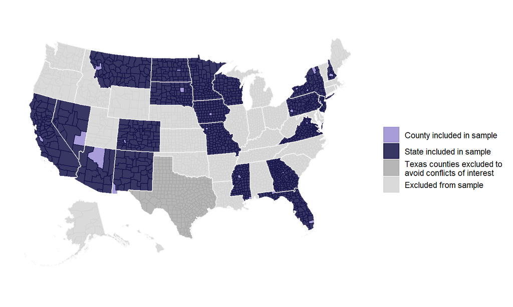

## Public accessibility

#### Criteria

- The dashboards were evaluated across 10 factors concerning the public accessibility of the dashboard
- Two factors fell into the category: *Accessibility*
- Three factors fell into the category: *Communication*
- Five factors fell into the category: *Data integrity and system quality*

#### Results

- Lincoln County, NV (a state dashboard) scored the highest (**90%**) across public accessibility factors
- Language translation was the most common public accessibility criterion that was **not** met
  - **83%** of dashboards were only available in English
  - The four dashboards which did provide language translation were all translated into Spanish

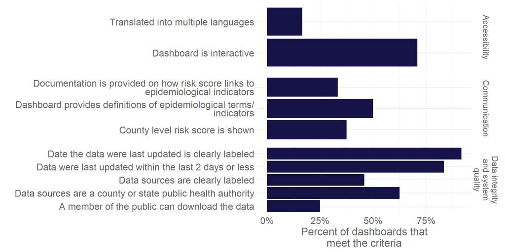

## Public accessibility - Accessibility

#### Best practices

- Two indicators were identified as best practices to monitor accessibility
- *Dashboard is interactive*
- *Translated into multiple languages*

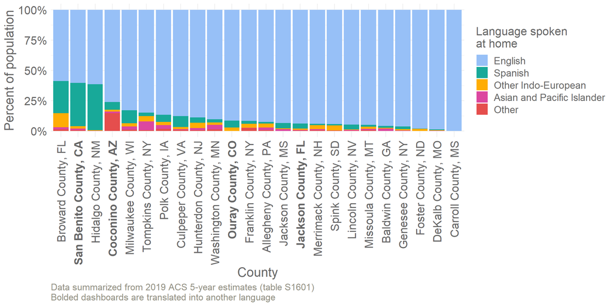

#### Results - Interactivity

- **29%** of the dashboards were **not** interactive
  - **33%** of county dashboards were **not** interactive, compared to **22%** of state dashboards
- Four of the dashboards evaluated were PDFs
- Only two county dashboards and two state dashboards were translated into another language

#### Results - Language translation

- The sampled counties contain diverse speaking populations
  - In nine counties, **10%** of the county population primarily speaks a language besides English at home
- In three counties, **25%** of the county population primarily speaks Spanish at home
  - Of these three counties, only **one** dashboards provided a Spanish translation

## Public accessibility - Communication

#### Best practices

- Three indicators were identified as best practices to monitor communication
- *Dashboard provides definitions of epidemiological terms/indicators*
- *County level risk score is shown*
- *Documentation is provided on how risk score links to epidemiological indicators*

#### Results - Epidemiologic terms and indicators

- Many dashboards could have included more documentation of epidemiological terminology and indicators
  - Overall, only **50%** dashboards included explanations of epidemiological terminology and indicators
- This percentage differed between state- and county- maintained dashboards
  - **27%** of county dashboards included explanations of their terminology compared to **89%** of state dashboards

##### Allegheny county, PA county dashboard

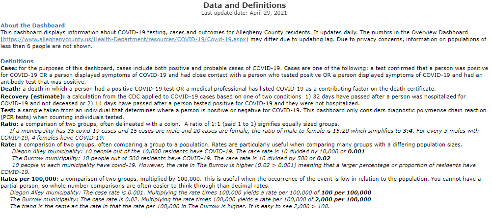

## Public accessibility - Communication

#### Results - County risk score

##### Coconino County, AZ county dashboard

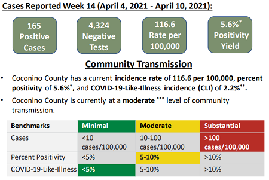

#### Results - Linking risk score to epidemiological indicators

##### Nevada state dashboard

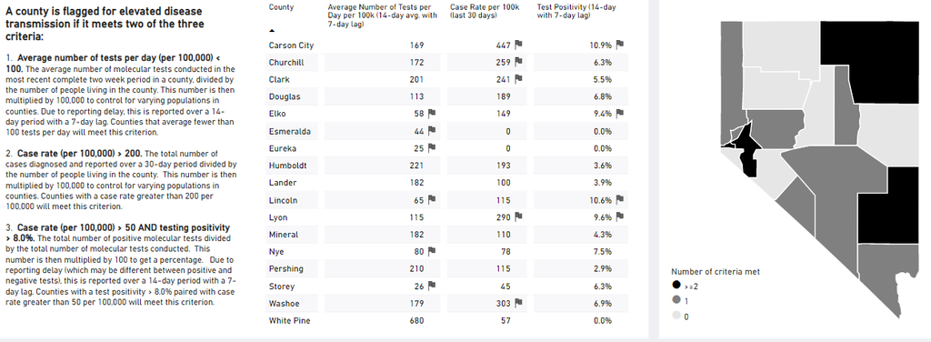

## Public accessibility - Data integrity and system quality

#### Best practices

- Five indicators were identified as best practices to monitor data integrity and system quality
- *Data sources are clearly labeled*
- *Data sources are a county or state public health authority*
- *Date the data were last updated is clearly labeled*
- *Data were last updated within the last 2 days or less*
- *A member of the public can download the data*

#### Results - Data system quality

- The vast majority (**92%**) of dashboards clearly labeled the date their data were last updated
- **83%** of dashboards update their data regularly (within two days of review), with similar percentages for state and county dashboards
  - All of these dashboards regularly update case data, while **90%** update deaths data and **71%** update testing data
- The four counties that did **not** update their data within two days of review update their data weekly
- Only six (**25%**) of dashboards allow the user to download the data
  - Five of these are state dashboards

## Epidemiological completeness

#### Criteria

- The dashboards were evaluated across 25 factors concerning their epidemiological rigor
- 12 factors fell into the category: *Disease situation*
- 11 factors fell into the category: *Disease control*
- Two factors fell into the category: *Health care system*

#### Results

- Allegheny County, PA (a county dashboard) scored the highest (**52%**) across epidemiology completeness factors
- The most commonly reported metric was *daily new cases at the county level*
  - However, only **58.3%** of dashboards reported this metric
- **None** of the dashboards in this sample reported *median/average time from specimen collection to isolation of cases*, *percent of new cases epidemiologically linked to at least one other case*, *median/average diagnostic test turnaround time*, or *daily COVID-19 hospitalizations as a moving average*
- The average percent of criteria met did **not** differ between county- and state-maintained dashboards (**22.5%** vs **23.7%**)

## Epidemiological completeness - Disease situation

#### Best practices - Cases

- Four indicators were identified as best practices to monitor case incidence
- *Dashboard reports daily new cases at the county level*
- *Dashboard reports daily new cases per capita at the county level*
- *Dashboard reports daily new cases with a moving average at the county level*
- *Dashboard reports confirmed and probable cases at the county level*

#### Results

- **58%** of dashboards reported *daily COVID-19 cases at the county level*
  - In our sample, a higher proportion of county dashboards (**66.7%**) reported daily COVID-19 cases at the county level than state dashboards (**44%**)
- Fewer dashboards reported the metric *daily COVID-19 cases with a moving average at the county level* (**33%**) and the metric *daily COVID-19 cases per capita at the county level* (**8%**)
  - Only two dashboards reported all three case indicators

#### Alternative ways to display case incidence

- Several dashboards still report cumulative cases at the weekly level or cumulative case counts for the county
- Several of the state dashboards provide a graph showing daily COVID-19 cases but do **not** provide users with the ability to drill down to their county

##### Case data for Baldwin County, Georgia state dashboard

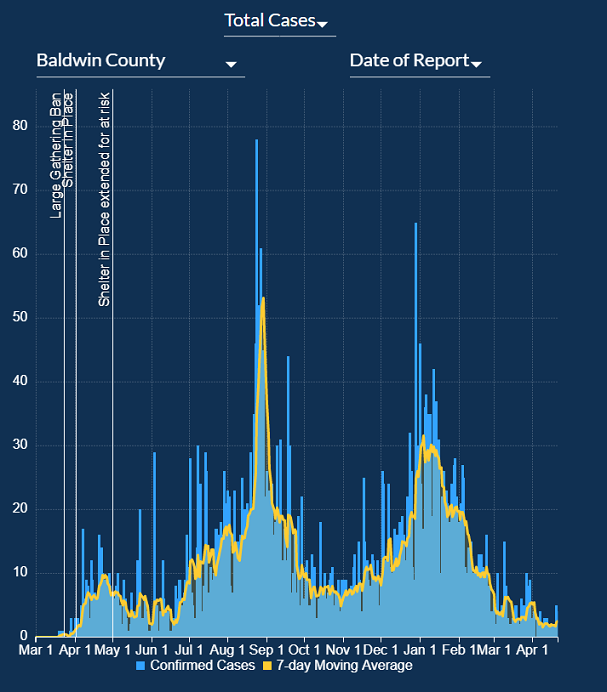

## Epidemiological completeness - Disease situation

#### Best practices - Demographics

- Four best practices were identified to monitor demographic characteristics
- *Dashboard reports case data stratified by any demographics (e.g. sex, race/ethnicity, age) at the county level*
- *Dashboard reports testing data stratified by any demographics (e.g. sex, race/ethnicity, age) at the county level*
- *Dashboard reports test positivity rate stratified by any demographics (e.g. sex, race/ethnicity, age) at the county level*
- *Dashboard reports deaths data stratified by any demographics (e.g., sex, race/ethnicity, age) at the county level*

#### Results - Cases

- Out of 24 dashboards, **58%** stratified cases by age, sex, or race/ethnicity
- In this sample it was more common for county dashboards to report demographic information that state dashboards (**67%** vs **44%**)
- Some dashboards stratified deaths by demographics, but did **not** regularly update their demographic data

#### Results - Testing and test positivity rate

- **83%** of dashboards did **not** include any testing demographics
- Very few dashboards stratified the test positivity rate by any demographic characteristics (**17%**)
  - This percentage was similar for both county and state dashboards

#### Results - Mortality

- It was **not** common for dashboards to stratify mortality by demographics
  - **33%** stratified cases by age, sex, or race/ethnicity
  - Slightly more county dashboards reported demographic information as state dashboards, **38%** vs **25%**, respectively

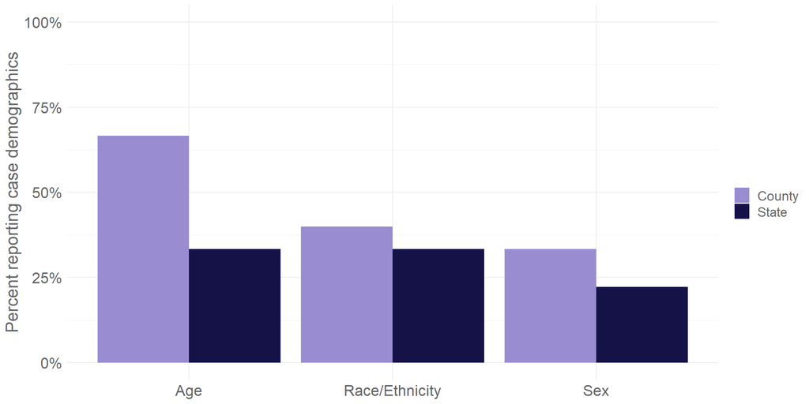

## Epidemiological completeness - Disease situation

#### Best practices - Syndromic surveillance

- Two indicators were identified as best practices to monitor syndromic surveillance trends
- *Dashboard reports COVID Like Illness (CLI) trends at the county level*
- *Dashboard reports Influenza Like Illness (ILI) trends at the county level*

#### Results

- It was uncommon for county and state dashboards to report syndromic surveillance indicators
  - Three reported CLI and only **one** reported ILI
  - Two dashboards linked to separate reports where the CLI and ILI were monitored for their region

##### Carroll County, MS state dashboard

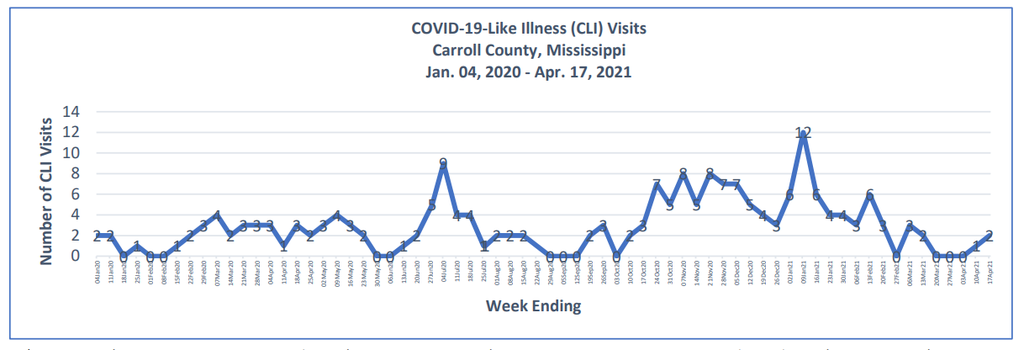

## Epidemiological completeness - Disease situation

#### Best practices - Mortality

- Four indicators were identified as best practices to monitor mortality
- *Dashboard reports daily deaths at the county level*
- *Dashboard reports daily deaths per capita at the county level*
- *Dashboard reports daily deaths with a moving average at the county level*
- *Dashboard reports confirmed and probable deaths at the county level*

#### Results

- Although the majority of dashboards included some indicator of COVID-19 mortality at the county level (20 dashboards), only a few contained the above best practices
- Seven dashboards reported daily deaths, daily deaths per capita, or daily deaths as a moving average
  - Six dashboards reported daily deaths
  - Two dashboards reported deaths per capita
  - Four dashboards reported deaths with moving averages
  - Six dashboards explicitly reported both confirmed and probable deaths

#### Alternative ways to display mortality

- State and county dashboards commonly reported mortality data as a cumulative count
  - 11 dashboards displayed their data as a cumulative count
  - Two dashboards displayed their data as a cumulative weekly count

## Epidemiological completeness - Disease control

#### Best practices - Testing

- Four indicators were identified as best practices to monitor testing
- *Dashboard reports daily total testing at the county level*
- *Dashboard reports daily total testing with a moving average at the county level*
- *Dashboard reports daily test positivity at the county level*
- *Dashboard reports daily test positivity with a moving average at the county level*

##### Allegheny county, PA county dashboard

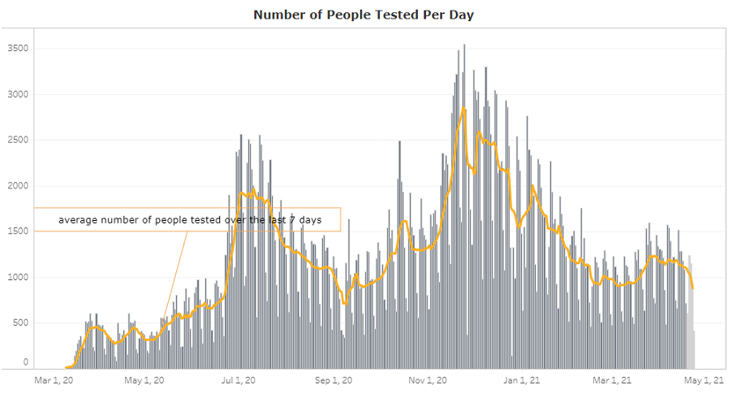

#### Results

- Overall, the majority of dashboards (**75%**) included some level of information on *COVID-19 testing at the county level*
  - The percentage of dashboards reporting testing data was similar between county and state dashboards
- However, only **33%** included information on *daily testing* at the county level
  - **22%** of dashboards reported data on *daily testing with a moving average*, with a slightly greater percentage of state dashboards reporting this metric (**29%** vs. **18%**)
- **44.4%** of dashboards included information on *daily test positivity* at the county level
  - **22%** of dashboards reported data on *daily test positivity with a moving average*, with a greater percentage of state dashboards reporting this metric (**29%** vs. **18%**)
- Only two dashboards reported all of the above metrics

## Epidemiological completeness - Disease control

#### Best practices - Congregate facilities

- One best practice was identified to monitor outbreaks in congregate care settings
- *Dashboard includes any data about cases or deaths at long-term care and congregate facilities at the county level*

##### North Dakota state dashboard

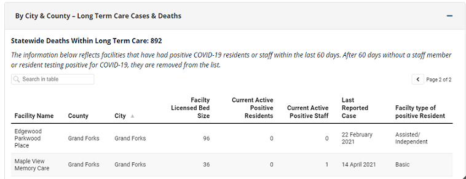

##### Franklin County, NY county dashboard

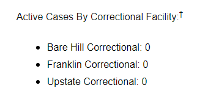

#### Results

- Dashboards did **not** commonly report data on case outbreaks and deaths in congregate care facilities at the county level
  - Only three dashboards reported any data on congregate care facilities at the county level
  - One dashboard provided data on cases/outbreaks within correctional facilities at the county level
  - Three dashboards provided data on cases/outbreaks within long-term care facilities
  - Three dashboards provided data on deaths within long-term care facilities
- Some dashboards did report data on case outbreaks and death, but they were either:
  - Not specific to congregate care facilities
  - Not at the county-level
- In the sample, **none** of the dashboards reported cases or outbreaks among homeless shelters or essential workplaces (e.g. the meatpacking industry)

## Epidemiological completeness - Disease control

#### Best practices - Contact tracing

- Two best practices were identified to monitor contract tracing
- *Dashboard reports median/average time from specimen collection to isolation of cases by week reported at the county level*
- *Dashboard reports the % of new cases epidemiologically linked to at least one other case*

#### Results

- It was **not** common for dashboards to report on contract tracing metrics
  - **None** of the dashboards in our sample reported *median/average time from specimen collection to isolation of cases by week reported at the county level*
  - **None** of the dashboards in our sample reported *the % of new cases epidemiologically linked to at least one other case*

##### Tompkins County, NY county dashboard

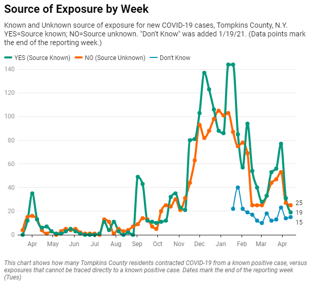

## Epidemiological completeness - Health care system

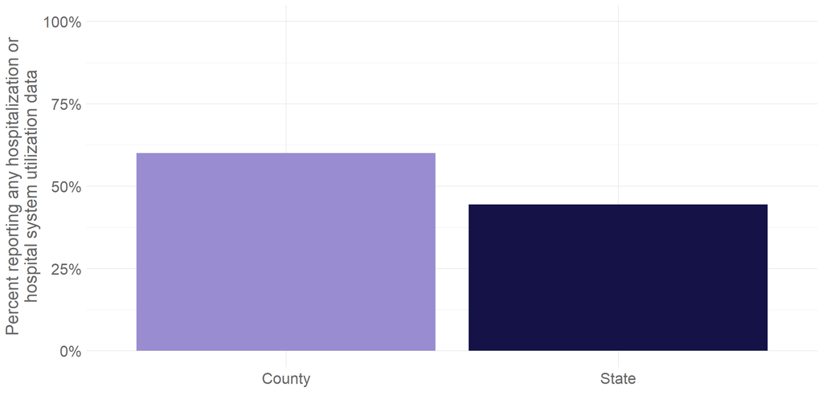

#### Best practices

- Two best practices were identified to monitor hospitalizations
- *Dashboard reports daily COVID-19 hospitalizations as a moving average at the county or regional level*
- *Dashboard reports daily % of licensed beds occupied by COVID-19 (confirmed or suspected) positive cases at the county or regional level*

#### Results

- While most dashboards did **not** report either of those specific metrics, many dashboards did report additional data on hospitalizations or hospital system utilization (**54.2%**)

## Conclusion

#### Health equity

- Significant gains in health equity could be made by standardizing metrics and risk thresholds and updating monitoring dashboards accordingly
- In many cases, health equity could also be improved if counties expanded demographic stratification beyond case incidence
- Counties should also monitor access to testing and severe outcomes such as hospitalization and deaths among different demographics

#### Public accessibility

- Many counties could improve the usability of their dashboards by including a color-coded risk threshold system with clear documentation about how the risk levels are linked to current indicators of COVID-19 community transmission
- Counties should consider adding multiple language options or providing key metrics in multiple languages to improve equitable access to information
- If possible, dashboard developers should automate data updates to ensure that data are updated regularly and not just on weekdays

#### Epidemiological completeness

- A range of indicators should be used to assess disease situation, control, and the state of the health care system
- These indicators should be provided as per capita rates and with moving averages to be able to easily compare to other jurisdictions and time periods
- Indicators should be expanded to include indicators of syndromic surveillance and hospital capacity